# Анализ закономерностей определяющих успешность компьютерной игры.

### Распределение продаж по платформам.

```python
df_platform=df.groupby('platform')['total_sales'].sum().reset_index().sort_values(
    by='total_sales', ascending=False)
display(df_platform)
```

|  | platform | total_sales |
| --- | --- | --- |
| 11 | ps2 | 1233.56 |
| 21 | x360 | 961.24 |
| 12 | ps3 | 931.33 |
| 18 | wii | 891.18 |
| 2 | ds | 802.76 |
| 10 | ps | 685.59 |
| 13 | ps4 | 314.14 |
| 4 | gba | 312.88 |
| 14 | psp | 289.53 |
| 0 | 3ds | 257.81 |
| 22 | xb | 251.57 |
| 8 | pc | 235.57 |
| 6 | n64 | 218.01 |
| 5 | gc | 196.73 |
| 23 | xone | 159.32 |
| 3 | gb | 136.30 |
| 19 | wiiu | 82.19 |
| 15 | psv | 53.81 |
| 16 | sat | 18.37 |
| 17 | snes | 17.39 |
| 1 | dc | 15.95 |
| 20 | ws | 1.42 |
| 7 | ng | 0.10 |
| 9 | pcfx | 0.03 |

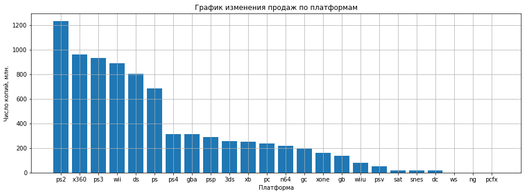

```python
plt.figure(figsize=(15, 5))
plt.bar(df_platform['platform'], df_platform['total_sales'])
plt.grid()
plt.xlabel('Платформа')
plt.ylabel('Число копий, млн.')
plt.title('График изменения продаж по платформам')
plt.show()
```

Диаграмма показывает, что по платформам продажи распределены крайне неравнометно. Наибольшие продажи на плотформе PS2, наименьшие на PCFX. Выберем платформы с продажами от 200 мнл. копий и построим графики распределения их продаж по годам.

```python
platform=list(df_platform.query('total_sales>200')['platform'].reset_index(drop=True))
```

C продажами свыше 200 млн. получилось 13 платформ.

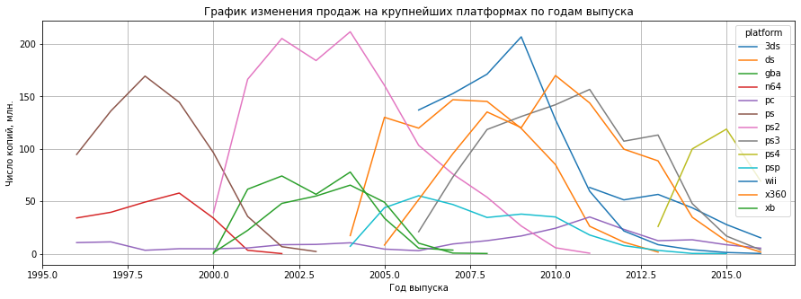

```python
df.query('platform==@platform')[['year_of_release', 'platform', 'total_sales']].pivot_table(
    index='year_of_release',
    columns='platform',
    values='total_sales',
    aggfunc='sum'
).plot(figsize=(15, 5), grid=True)
plt.xlabel('Год выпуска')
plt.ylabel('Число копий, млн.')
plt.title('График изменения продаж на крупнейших платформах по годам выпуска')
plt.show()
```

График думонстрирует, что для каждой платформы наблюдается период роста после появления и падения до окончательного исчезновения, причем в среднем период жизни платформы составляет 10 лет. Стоит отметить, что в районе 2016 года все платформы демонстрируют убывающую тенденцию. Это может быть связано с неполнотой данных и может внести искажения в последующие исследования. Поэтому имеет смысл исключить 2016 год из рассмотрения.

Для построения прогноза на 2017 примем период исследования 2014-2015 год.

```python
df1=df[df['year_of_release'].isin([2014, 2015])]
```

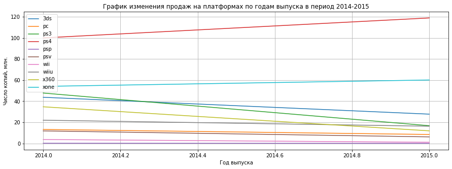

```python
all_platf(df1).plot(figsize=(15, 5), grid=True)
plt.xlabel('Год выпуска')
plt.ylabel('Число копий, млн.')
plt.title('График изменения продаж на платформах по годам выпуска в период 2014-2015')
plt.legend(loc='upper left')
plt.show()
```

Построим для всех платформ диаграмму размаха.

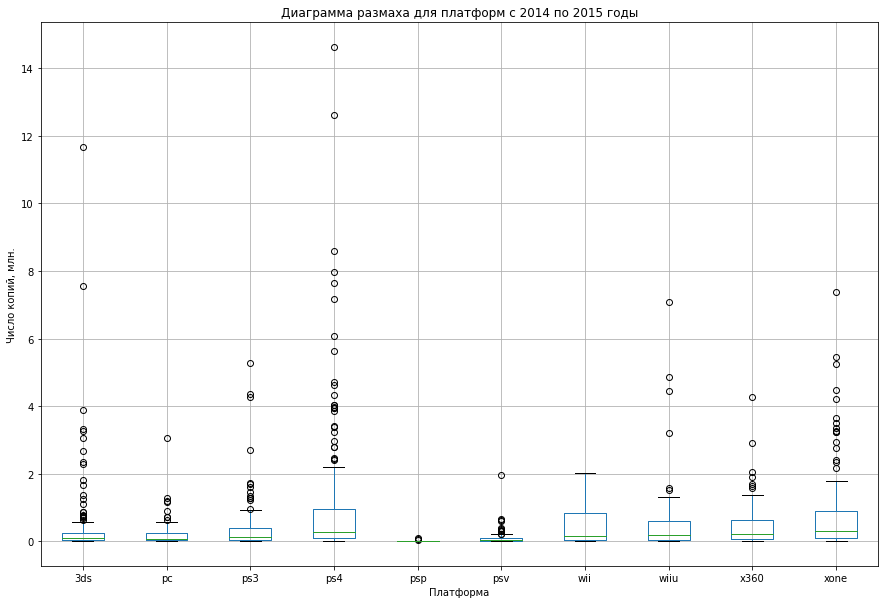

```python
df1.pivot(columns='platform', values='total_sales').boxplot(figsize=(15, 10), grid=True)
plt.xlabel('Платформа')
plt.ylabel('Число копий, млн.')
plt.title('Диаграмма размаха для платформ c 2014 по 2015 годы')
plt.show()
```

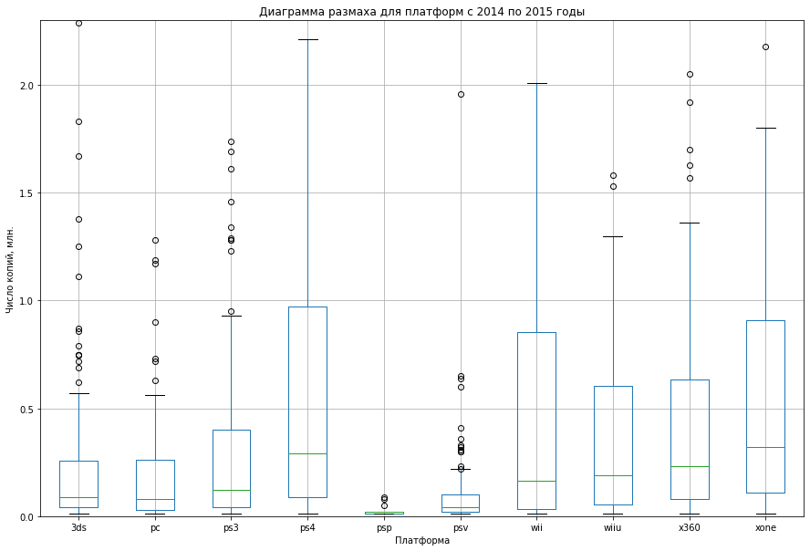

```python
df1.pivot(columns='platform', values='total_sales').boxplot(figsize=(15, 10), grid=True)
plt.xlabel('Платформа')
plt.ylabel('Число копий, млн.')
plt.ylim([0, 2.3])
plt.title('Диаграмма размаха для платформ c 2014 по 2015 годы')
plt.show()
```

```python
df1.pivot(columns='platform', values='total_sales').describe()
```

| platform | 3ds | pc | ps3 | ps4 | psp | psv | wii | wiiu | x360 | xone |
| --- | --- | --- | --- | --- | --- | --- | --- | --- | --- | --- |
| count | 166.000000 | 97.000000 | 181.000000 | 212.000000 | 13.000000 | 210.000000 | 10.000000 | 59.000000 | 98.000000 | 141.000000 |
| mean | 0.430964 | 0.224742 | 0.356796 | 1.032547 | 0.027692 | 0.086429 | 0.489000 | 0.650508 | 0.476531 | 0.810000 |
| std | 1.223959 | 0.391690 | 0.685857 | 1.935690 | 0.027735 | 0.162925 | 0.651928 | 1.275634 | 0.657035 | 1.220984 |
| min | 0.010000 | 0.010000 | 0.010000 | 0.010000 | 0.010000 | 0.010000 | 0.010000 | 0.010000 | 0.010000 | 0.010000 |
| 25% | 0.040000 | 0.030000 | 0.040000 | 0.090000 | 0.010000 | 0.020000 | 0.032500 | 0.055000 | 0.080000 | 0.110000 |
| 50% | 0.090000 | 0.080000 | 0.120000 | 0.290000 | 0.020000 | 0.040000 | 0.165000 | 0.190000 | 0.230000 | 0.320000 |
| 75% | 0.257500 | 0.260000 | 0.400000 | 0.972500 | 0.020000 | 0.100000 | 0.852500 | 0.605000 | 0.632500 | 0.910000 |
| max | 11.680000 | 3.050000 | 5.270000 | 14.630000 | 0.090000 | 1.960000 | 2.010000 | 7.090000 | 4.280000 | 7.390000 |

```python
platform_sales(df, 'ps2')
```

| year_of_release | total_sales | critic_score | user_score |
| --- | --- | --- | --- |
| 2000 | 39.17 | 72.0 | 7.85 |
| 2001 | 166.43 | 71.0 | 7.80 |
| 2002 | 205.38 | 71.0 | 7.90 |
| 2003 | 184.31 | 71.0 | 8.30 |
| 2004 | 211.81 | 69.5 | 8.10 |
| 2005 | 160.66 | 70.0 | 8.20 |
| 2006 | 103.42 | 68.0 | 7.90 |
| 2007 | 75.99 | 68.0 | 7.50 |
| 2008 | 53.90 | 67.0 | 7.25 |
| 2009 | 26.40 | 66.5 | 7.10 |
| 2010 | 5.64 | 77.0 | 6.90 |
| 2011 | 0.45 | NaN | 6.20 |

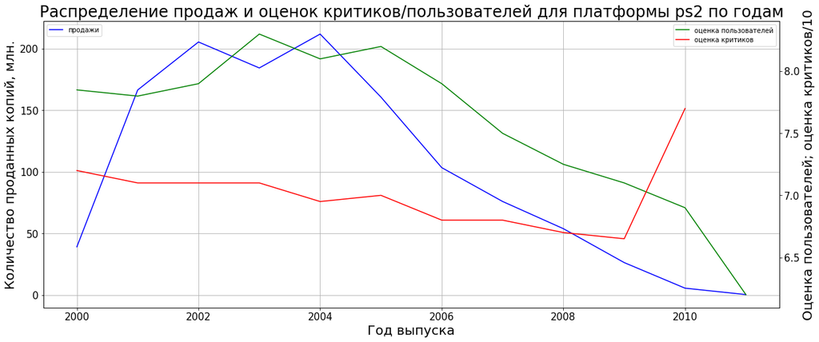

```python
col1 = 'green'
col2='blue'
col3='red'
fig,ax = plt.subplots(figsize=(20,8))
ax.set_title('Распределение продаж и оценок критиков/пользователей для платформы ps2 по годам', fontsize= 24)
ax.plot(platform_sales(df, 'ps2').index, platform_sales(df, 'ps2')['total_sales'], color=col2, label='продажи')
ax.set_xlabel('Год выпуска', fontsize= 20)
ax.set_ylabel('Количество проданных копий, млн.', fontsize= 20)
ax.legend(loc='upper left')
plt.tick_params (labelsize= 15)
ax2=ax.twinx()
ax2.plot(platform_sales(df, 'ps2').index, platform_sales(df, 'ps2')['user_score'], color=col1, label='оценка пользователей')
ax2.plot(platform_sales(df, 'ps2').index, platform_sales(df, 'ps2')['critic_score']/10, color=col3, label='оценка критиков')
ax2.set_ylabel('Оценка пользователей; оценка критиков/10', fontsize= 20)
plt.tick_params (labelsize= 15)
ax2.legend()
ax.grid()
```

Нельзя отрицать полного отсутствия влияния оценок на продажи, но обратимся к матрице корреляций и диаграммам рассеяния.

```
              total_sales  user_score  critic_score
total_sales      1.000000   -0.031957      0.406568
user_score      -0.031957    1.000000      0.557654
critic_score     0.406568    0.557654      1.000000
              total_sales  user_score  critic_score
total_sales      1.000000   -0.068925      0.416998
user_score      -0.068925    1.000000      0.472462
critic_score     0.416998    0.472462      1.000000
              total_sales  user_score  critic_score
total_sales      1.000000    0.114187      0.392866
user_score       0.114187    1.000000      0.625020
critic_score     0.392866    0.625020      1.000000
              total_sales  user_score  critic_score
total_sales      1.000000    0.400219       0.34838
user_score       0.400219    1.000000       0.77008
critic_score     0.348380    0.770080       1.00000
              total_sales  user_score  critic_score
total_sales      1.000000    0.112831      0.177907
user_score       0.112831    1.000000      0.688285
critic_score     0.177907    0.688285      1.000000
```

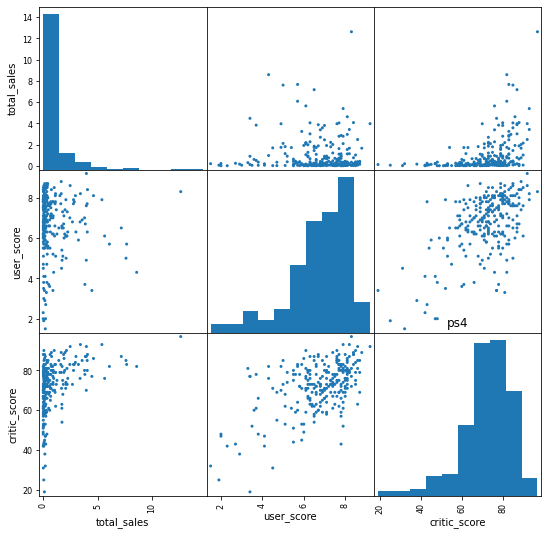

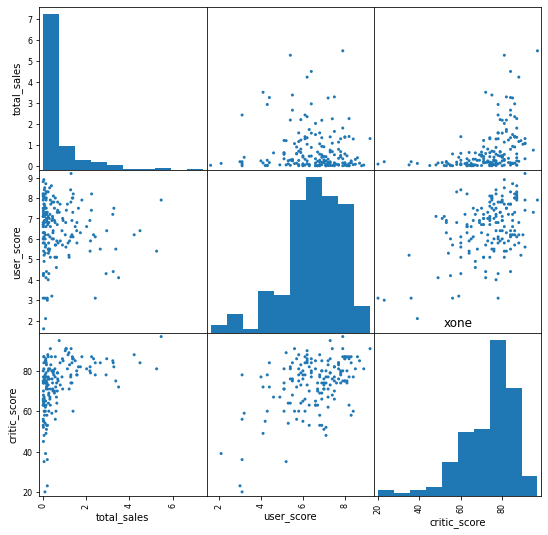

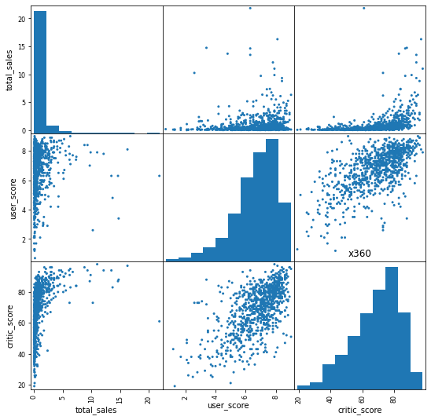

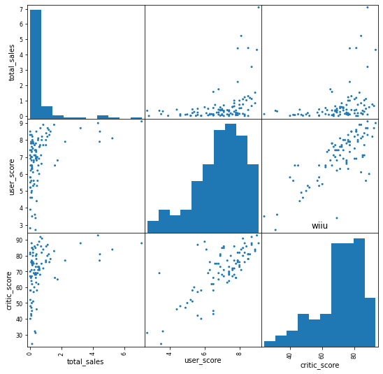

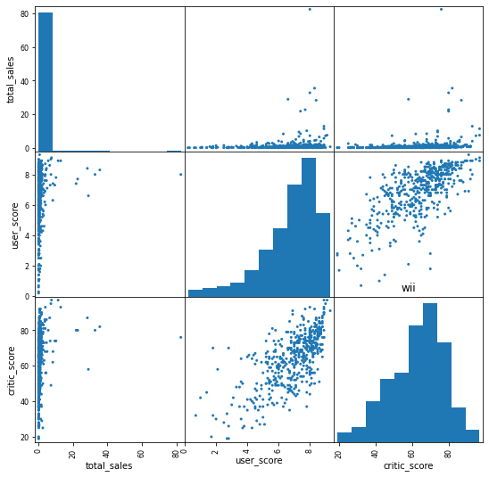

```python
for i in ['ps4', 'xone', 'x360', 'wiiu', 'wii']:
    pd.plotting.scatter_matrix(df[df['platform'].isin([i])][['total_sales', 'user_score', 'critic_score']], figsize=(9, 9), alpha=1)
    plt.title(i)
    print(df[df['platform'].isin([i])][['total_sales', 'user_score', 'critic_score']].corr())
```